# Plotting invasive species distributions with alpha shapes and choropleth maps in Python

Invasive and introduced species can expand quickly into new habitats, altering ecosystems. In this post we use Python’s {galah}, {alphashape} and {GeoPandas} packages to visualise the growing distribution of *Rhinella marina* (cane toads) and the expanding range of *Pittisporum undulatum* in Australia.

Eukaryota

Animalia

Plantae

Maps

Python

Authors

Caitlin Ramsay

Amanda Buyan

Dax Kellie

Published

April 28, 2023

Modified

October 23, 2026

#### Author

Caitlin Ramsay  
[Amanda Buyan](https://labs.ala.org.au/about/Buyan_Amanda/index.html)  
[Dax Kellie](https://labs.ala.org.au/about/Kellie_Dax/index.html)

#### Date

28 April 2023

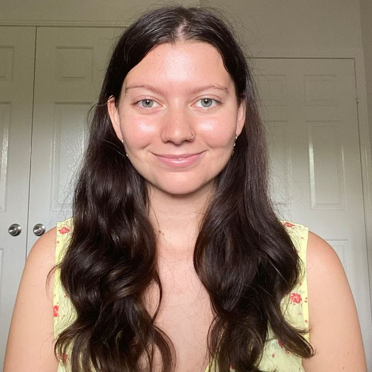

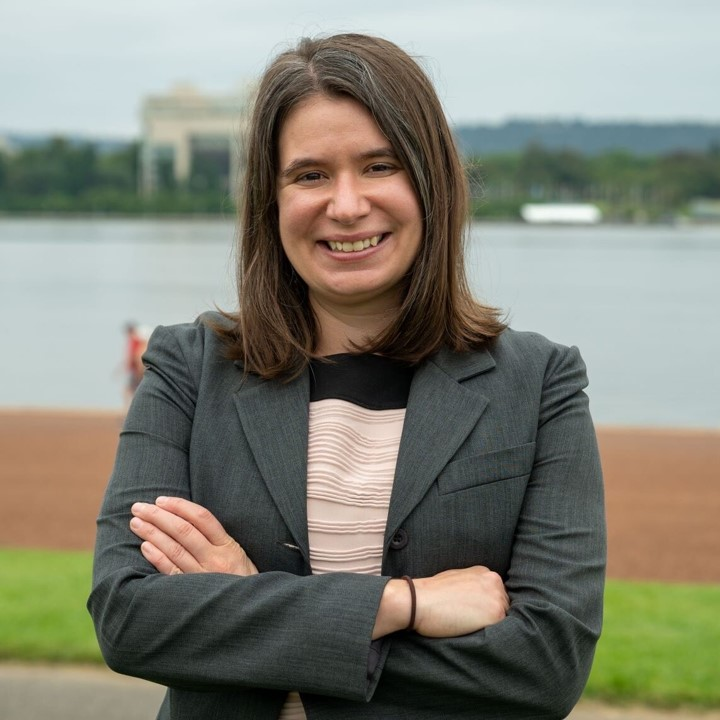

**TipIntern Post**

Humans’ movement across the globe has led to the accidental, and sometimes deliberate, transportation of species beyond their native habitats. In Australia since European colonisation, [around 3,000 species have been introduced](https://cloud.gbif.org/griis/resource?r=griis-australia).

Within the last 200 years [over 100 native species have gone extinct](https://theconversation.com/invasive-species-are-australias-number-one-extinction-threat-116809), with invasive species labelled as affecting [82% (1,257 of 1,533) of Australia’s threatened taxa in 2018](https://soe.dcceew.gov.au/overview/pressures/invasive-species-and-range-shifts#impacts-of-invasive-species). Since 1960, invasive species have cost the Australian economy [at least $390 billion in damages](https://theconversation.com/pest-plants-and-animals-cost-australia-around-25-billion-a-year-and-it-will-get-worse-164969), and are now considered a main driver of extinctions in native plants and animals.

However, species from outside of Australia aren’t the only ones that can encroach on other species’ habitats. [Native Australian species can do it, too](https://phys.org/news/2021-08-australian-native-invasive-species.html). Thanks in part to human activity, changing temperatures and more frequent extreme weather events, some Australian species have established themselves in new areas outside of their native range. Although not as popularly discussed, Australian species that have become pests in new habitats can disrupt ecosystems much like internationally invasive species.

In this post, we will use Python and the [{galah} package](https://galah.ala.org.au/) to visualise how distributions of both international invasive species and native introduced pest species have shifted over time. To do this, we will use alpha shapes to visualise the distribution of *Rhinella marina* (Cane toads) since the 1930s and create a choropleth map to visualise the expanded habitat range of *Pittosporum undulatum*.

# Invasive Species

### Download data

To start, we will use the infamous example of the cane toad to illustrate how far an invasive species’ distribution can spread each decade.

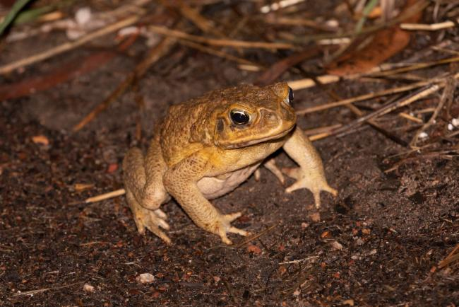

[Rhinella marina (Isaac Clarey CC-BY-NC 4.0 (Int))](https://biocache.ala.org.au/occurrences/722881a9-aff8-40f9-af5d-fe6bea58743d)

First load the required Python packages.

```python
import galah
import pandas as pd
import geopandas
import numpy as np
from dateutil.parser import parse
import matplotlib.pyplot as plt
import matplotlib as mpl
import alphashape
from flexitext import flexitext
```

Next, we will use the [{galah} package](https://galah.ala.org.au/Python/index.html) to download occurrence records of cane toads in Australia from the Atlas of Living Australia (ALA). You will need to first provide a registered email with the ALA using `galah.galah_config()` before retrieving records.

```python
# Add registered email (register at ala.org.au)
galah.galah_config(email = "your-email@email.com")
galah.galah_config(data_profile="ALA")
```

```python
cane_toads = galah.atlas_occurrences(taxa = "Rhinella marina", use_data_profile = True)
cane_toads.head(5)
```

|  | recordID | scientificName | taxonConceptID | decimalLatitude | decimalLongitude | eventDate | dataResourceName | occurrenceStatus |
| --- | --- | --- | --- | --- | --- | --- | --- | --- |
| 0 | 0000bedd-4261-424a-bae1-8856cf9d6775 | Rhinella marina | https://biodiversity.org.au/afd/taxa/c4e7f0cb-... | -12.617330 | 132.341660 | 2014-04-14T00:00:00Z | Fauna Atlas N.T. | PRESENT |
| 1 | 0001a709-3641-4357-9f7b-1b3bc4aba5a9 | Rhinella marina | https://biodiversity.org.au/afd/taxa/c4e7f0cb-... | -27.644640 | 153.052273 | 2022-05-17T20:31:00Z | iNaturalist Australia | PRESENT |
| 2 | 0003d635-b5af-42a8-aa1b-ca509a90cec9 | Rhinella marina | https://biodiversity.org.au/afd/taxa/c4e7f0cb-... | -24.184920 | 151.086840 | 2023-11-27T00:00:00Z | WildNet - Queensland Wildlife Data | PRESENT |
| 3 | 0003dc15-b637-455b-b872-f8624058c25b | Rhinella marina | https://biodiversity.org.au/afd/taxa/c4e7f0cb-... | -12.628827 | 130.930645 | NaN | Fauna Atlas N.T. | PRESENT |
| 4 | 0004b1b4-deb9-44da-90ef-6642e687b1a9 | Rhinella marina | https://biodiversity.org.au/afd/taxa/c4e7f0cb-... | -16.478644 | 125.126274 | 2022-05-15T00:00:00Z | AWC Ecological Monitoring Surveys | PRESENT |

### Clean data

We’ll clean our data to ensure that there are no null or missing values in our coordinates and date fields. Because `galah.atlas_occurrences()` returns a Pandas dataframe, we have plenty of functions we can use to clean our data.

```python
cane_toads = cane_toads.dropna(subset=["eventDate", "decimalLatitude", "decimalLongitude"])
```

We want to map cane toad’s distribution each decade in our final visualisation. However, the `eventDate` value for each record is formaatted as a string value `yyyy-mm-dd Thh:mm:ssZ`. Let’s write our own function `convert_date_to_decade()` that extract the year from a date `string` and return its corresponding decade by rounding down to the nearest decade.

```python
def convert_date_to_decade(value):
    date = parse(value)
    return date.year - (date.year%10)
```

We’ll create our new `decade` column by mapping each record’s date value in `eventDate` to its corresponding decade value.

```python
cane_toads["decade"] = cane_toads["eventDate"].map(convert_date_to_decade)
```

### Make Australia map

Next, let’s download a shapefile of Australia with state boundaries. The Australian Bureau of Statistics provides [digital boundary files](https://www.abs.gov.au/statistics/standards/australian-statistical-geography-standard-asgs-edition-3/jul2021-jun2026/access-and-downloads/digital-boundary-files) from which you can explore many other Australian shapefiles. Download the [States and Territories - 2021 - Shapefile](https://www.abs.gov.au/statistics/standards/australian-statistical-geography-standard-asgs-edition-3/jul2021-jun2026/access-and-downloads/digital-boundary-files/STE_2021_AUST_SHP_GDA2020.zip) a zip folder. Save the zip folder inside your working folder and then unzip it to access the `.shp` file inside.

{`GeoPandas`} is a package that handles geospatial data in Python and can be used to load in shapefiles as `GeoPandas` dataframes. Let’s test this out by plotting our Australian state boundary shapefile.

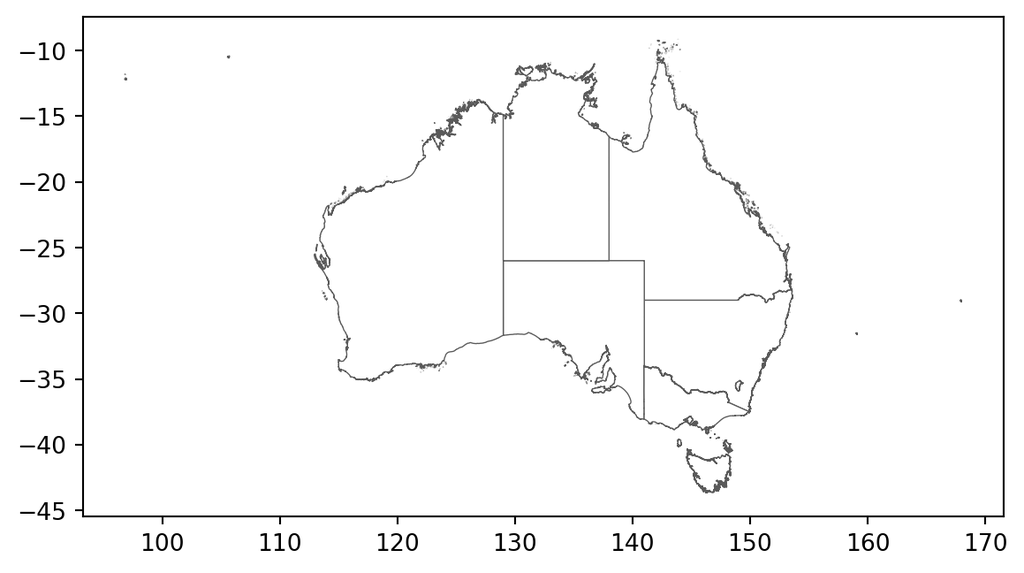

```python
states = geopandas.read_file("Australia_state_boundaries/STE_2021_AUST_GDA2020.shp")
states.plot(edgecolor = "#5A5A5A", linewidth = 0.5, facecolor = "white")
```

### Generate alpha shapes

Alpha shapes can be used to define and visualise the shape of a set of species occurrence points in space. They are useful because they can be generated on *data-deficient* species with few available observations, and without using environmental data or complex algorithms. Let’s use alpha shapes to see how cane toads’ distribution has changed each decade since they were introduced.

First, we need to obtain a list of all decades with cane toad observations. We’ll use the `decade` column from our `cane_toads` dataframe to group our observations.

```python
decades = list(set(cane_toads["decade"]))
```

We will be using the [{`alphashape`} package](https://pypi.org/project/alphashape/) to create alpha shapes representing the cane toad distribution for each decade they have been observed. The alphashape.alphashape() function requires two things:

1. A set of observation coordinates
2. An alpha parameter, which sets how tightly the shape’s lines conform to our observations

Let’s make an alpha shape for each decade’s observations. We’ll also add a slight buffer to each alpha shape to smooth out some of its edges. Then we’ll group all the shapes into one large `GeoPandas` dataframe.

**Note**

We used `alpha = 1`, but it’s good practice to change this parameter depending on how widely distributed the coordinates of your data are. Also note that `alphashape.alphashape()` requires at least 3 data points to calculate an alpha shape.

```python
alpha_shape_gdf = geopandas.GeoDataFrame() # GeoPandas data frame to contain all alpha shapes
for i, d in enumerate(decades):
    decade_points = cane_toads[["decimalLongitude", "decimalLatitude"]] [cane_toads["decade"] == d]
    if len(decade_points) <= 3:
        continue
    alpha_shape = alphashape.alphashape(decade_points, 1)
    d = {"decade": d, "geometry": [alpha_shape.buffer(0.2)]}
    tmp_gdf = geopandas.GeoDataFrame(d, crs="EPSG:7844")
    alpha_shape_gdf = pd.concat([alpha_shape_gdf, tmp_gdf])
```

Next, let’s clean up our `GeoPandas` dataframe so that it is ready for plotting! Sometimes the `alphashape.alphashape()` algorithm will produce an empty shape that needs to be removed from the dataframe (this generally happens when the chosen alpha parameter is not appropriate for the supplied set of points). Let’s remove these shapes from our data.

```python
alpha_shape_gdf = alpha_shape_gdf[~alpha_shape_gdf["geometry"].is_empty]
```

Now let’s format our decade string to display correctly on the figure legend by making sure it’s in `YYYYs` format.

```python
alpha_shape_gdf["decade_string"] = alpha_shape_gdf["decade"].map(lambda d: str(d) + "s")
```

Finally, because we expect cane toad distributions in earlier decades to be smaller than in recent decades, we’ll need to plot earlier distributions *on top* of later distributions to avoid covering the earlier ones up. To achieve this, let’s order the alpha shapes in descending order by decade.

```python
alpha_shape_gdf.sort_values(by='decade', ascending=False, inplace=True)
```

### Map alpha shape distributions

Finally, we can plot our alpha shape distributions for each decade onto our map of Australia!

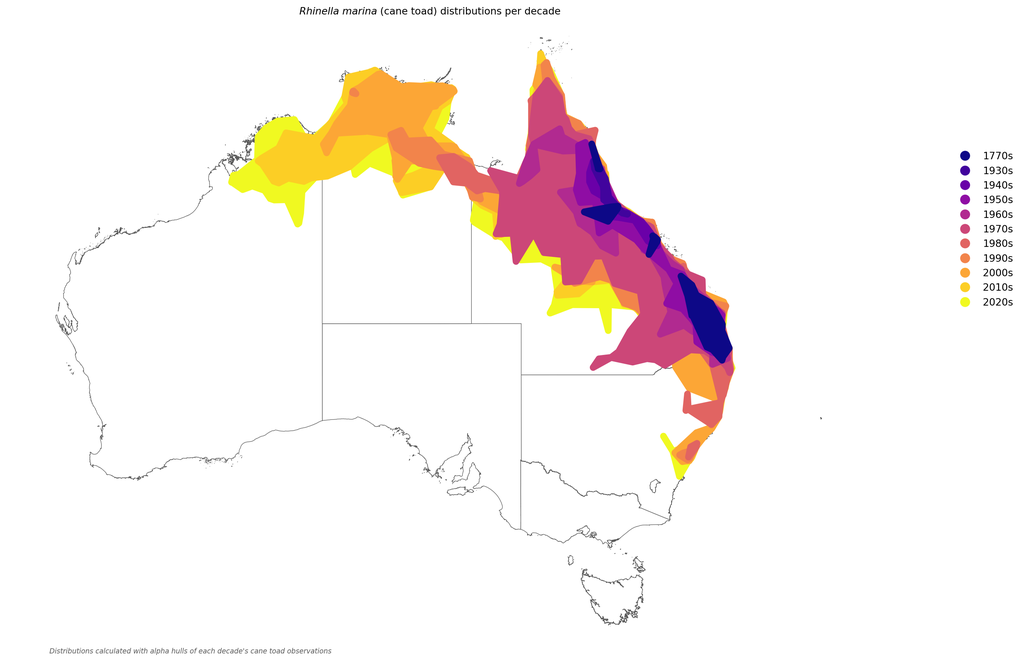

Figure 1: Map

```python
with plt.rc_context({"figure.figsize": (16, 11.5)}):
    ax = states.boundary.plot(edgecolor="#5A5A5A", linewidth=0.5, facecolor="white", zorder=-1)

    alpha_shape_gdf.plot(ax = ax, cmap="plasma", column = "decade_string", legend=True, categorical=True)
    lgd = ax.get_legend()
    lgd.draw_frame(False)
    lgd.set_bbox_to_anchor((1.2, 0.8))

    title_text = "<style: italic>Rhinella marina</> (cane toad) distributions per decade"
    flexitext(0.5, 1, title_text, va="bottom", ha="center");

    caption_text = "<color:#5A5A5A, style:italic, size:7>Distributions calculated with alpha hulls of each decade's cane toad observations</>"
    flexitext(0.05, 0, caption_text, va="top");

    plt.xlim([110, 161])
    plt.ylim([-45, -8])
    plt.axis("off")
    plt.subplots_adjust(left=-0.15, right=1)

    plt.show()
```

### Other invasive species

Let’s use the same code as above to visualise other invasive species *Camelus dromedarius* (Feral dromedary camels) and *Echium plantagineum* (Paterson’s curse).

**Camels**

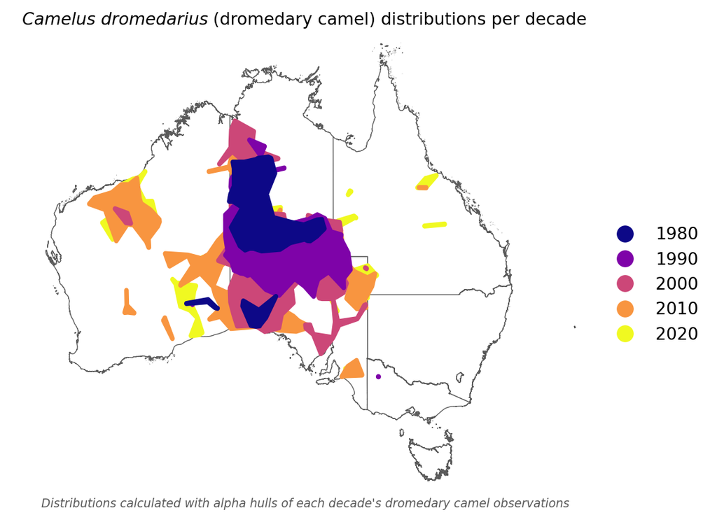

```python
# Camel
camels = galah.atlas_occurrences("Camelus dromedarius", use_data_profile="ALA")
camels = camels.dropna(subset=["eventDate", "decimalLatitude", "decimalLongitude"])
camels["decade"] = camels["eventDate"].map(convert_date_to_decade)
decades = list(set(camels["decade"]))

alpha_shape_gdf = geopandas.GeoDataFrame() # GeoPandas data frame to contain all alpha shapes

for i, d in enumerate(decades):
    decade_points = camels[["decimalLongitude", "decimalLatitude"]] [camels["decade"] == d]
    if len(decade_points) <= 3:
        continue
    alpha_shape = alphashape.alphashape(decade_points, 1)
    d = {"decade": d, "geometry": [alpha_shape.buffer(0.2)]}
    tmp_gdf = geopandas.GeoDataFrame(d, crs="EPSG:4326")
    alpha_shape_gdf = pd.concat([alpha_shape_gdf, tmp_gdf])

alpha_shape_gdf = alpha_shape_gdf[ ~alpha_shape_gdf["geometry"].is_empty]
alpha_shape_gdf["decade_string"] = alpha_shape_gdf["decade"].map(lambda d: str(d) + "s")
alpha_shape_gdf.sort_values(by='decade', ascending=False, inplace=True)

ax = states.boundary.plot(edgecolor="#5A5A5A", linewidth=0.5, facecolor="white", zorder=-1)

alpha_shape_gdf.plot(ax = ax, cmap="plasma", column = "decade", legend=True, categorical=True)
lgd = ax.get_legend()
lgd.draw_frame(False)
lgd.set_bbox_to_anchor((1.2, 0.61))

title_text = "<style: italic>Camelus dromedarius</> (dromedary camel) distributions per decade"
flexitext(0.5, 1, title_text, va="bottom", ha="center");

caption_text = "<color:#5A5A5A, style:italic, size:7>Distributions calculated with alpha hulls of each decade's dromedary camel observations</>"
flexitext(0.05, 0, caption_text, va="top");

plt.xlim([110, 161])
plt.ylim([-45, -8])
plt.axis("off")
plt.subplots_adjust(left=-0.1, right=1)

plt.show()
```

**Patterson’s curse**

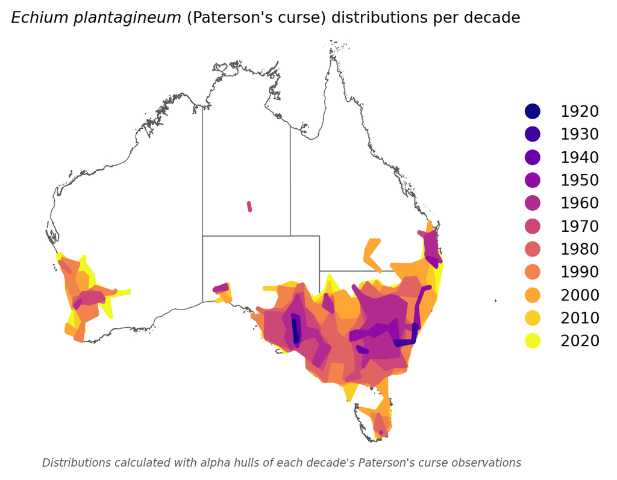

```python
# Paterson's Curse
opuntia = galah.atlas_occurrences("Echium plantagineum", use_data_profile="ALA")
opuntia = opuntia.dropna(subset=["eventDate", "decimalLatitude", "decimalLongitude"])
opuntia["decade"] = opuntia["eventDate"].map(convert_date_to_decade)
decades = list(set(opuntia["decade"]))

alpha_shape_gdf = geopandas.GeoDataFrame() # GeoPandas data frame to contain all alpha shapes

for i, d in enumerate(decades):
    decade_points = opuntia[["decimalLongitude", "decimalLatitude"]] [opuntia["decade"] == d]
    if len(decade_points) <= 3:
        continue
    alpha_shape = alphashape.alphashape(decade_points, 1)
    d = {"decade": d, "geometry": [alpha_shape.buffer(0.2)]}
    tmp_gdf = geopandas.GeoDataFrame(d, crs="EPSG:4326")
    alpha_shape_gdf = pd.concat([alpha_shape_gdf, tmp_gdf])

alpha_shape_gdf = alpha_shape_gdf[ ~alpha_shape_gdf["geometry"].is_empty]
alpha_shape_gdf["decade_string"] = alpha_shape_gdf["decade"].map(lambda d: str(d) + "s")
alpha_shape_gdf.sort_values(by='decade', ascending=False, inplace=True)

ax = states.boundary.plot(edgecolor="#5A5A5A", linewidth=0.5, facecolor="white", zorder=-1)

alpha_shape_gdf.plot(ax = ax, cmap="plasma", column = "decade", legend=True, categorical=True)
lgd = ax.get_legend()
lgd.draw_frame(False)
lgd.set_bbox_to_anchor((1.2, 0.85))

title_text = "<style: italic>Echium plantagineum</> (Paterson's curse) distributions per decade"
flexitext(0.5, 1, title_text, va="bottom", ha="center");

caption_text = "<color:#5A5A5A, style:italic, size:7>Distributions calculated with alpha hulls of each decade's Paterson's curse observations</>"
flexitext(0.05, 0, caption_text, va="top");

plt.xlim([110, 161])
plt.ylim([-45, -8])
plt.axis("off")
plt.subplots_adjust(left=-0.1, right=1)

plt.show()
```

# Native introduced pest species

When people think of invasive species, they generally think of species that have been introduced to Australia from other countries. However, even Australia’s native species can become pests when introduced to a new ecosystem.

One good example of native pests are the trees *Pittosporum undulatum* (sometimes called Sweet Pittosporum). These trees have been introduced as ornamental plants in gardens across Australia because of their sweet-scented flowers and bright berries. Although *Pittosporum undulatum*’s native range extends from southern Queensland to eastern Victoria, it is now considered an environmental weed in many regions where it has been introduced.

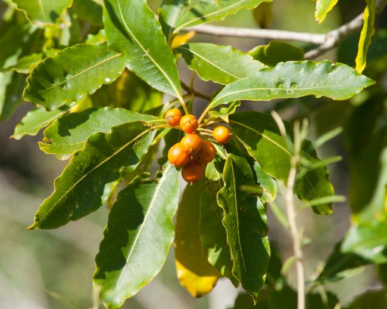

[Pittosporum undulatum (Chris Clarke CC-BY)](https://biocache.ala.org.au/occurrences/30b0b6dc-1d77-4a1f-ae15-18ef5ef67e28)

Let’s create a choropleth map to visualise the to visualise the bioregions where *Pittosporum undulatum* is native and introduced.

### Download IBRA regions

First, let’s download a shapefile of Australia’s bioregions. The [IBRA7 bioregions](https://data.gov.au/dataset/ds-dga-d44dd392-ebea-4f1a-b30e-4a2da154aae4/details?q=ibra) classify areas within Australia that are geographically and ecologically distinct. Download the zip folder, save it in your project directory and unzip it. We can again use the {GeoPandas} package to read in and handle these data.

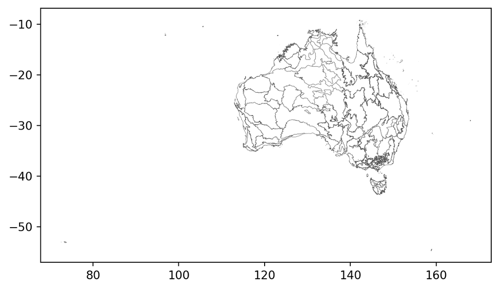

```python
bioregions = geopandas.read_file("IBRA7_regions/ibra7_regions.shp")
bioregions.plot(edgecolor = "#5A5A5A", linewidth = 0.25, facecolor = "white")
```

Within our `bioregions` dataframe, the column `REG_NAME_7` contains IBRA bioregion names.

```python
bioregions.head(5)
```

|  | REG_CODE_7 | REG_NAME_7 | HECTARES | SQ_KM | REC_ID | REG_CODE_6 | REG_NAME_6 | REG_NO_61 | FEAT_ID | Shape_Leng | Shape_Area | geometry |
| --- | --- | --- | --- | --- | --- | --- | --- | --- | --- | --- | --- | --- |
| 0 | ARC | Arnhem Coast | 3.335669e+06 | 33356.686 | 1 | ARC | Arnhem Coast | 81.0 | GA_100K_Islands | 52.135362 | 2.774143 | MULTIPOLYGON (((136.93863 -14.36548, 136.9379 ... |
| 1 | ARP | Arnhem Plateau | 2.306023e+06 | 23060.226 | 2 | ARP | Arnhem Plateau | 82.0 | GA_100K_Mainland | 8.206764 | 1.921833 | POLYGON ((134.08186 -12.32124, 134.09525 -12.3... |
| 2 | AUA | Australian Alps | 1.232981e+06 | 12329.805 | 3 | AA | Australian Alps | 6.0 | GA_100K_Mainland | 63.337626 | 1.242821 | MULTIPOLYGON (((145.75905 -37.67486, 145.76034... |
| 3 | AVW | Avon Wheatbelt | 9.517104e+06 | 95171.043 | 4 | AW | Avon Wheatbelt | 70.0 | GA_100K_Mainland | 35.275357 | 9.012298 | POLYGON ((115.48396 -28.30698, 115.48428 -28.3... |
| 4 | BBN | Brigalow Belt North | 1.367453e+07 | 136745.325 | 5 | BBN | Brigalow Belt North | 22.0 | GA_100K_Islands | 91.288203 | 11.986228 | MULTIPOLYGON (((151.14295 -23.71304, 151.1421 ... |

### Find bioregions with observations

We’ll once again use {galah} to find numbers of *Pittosporum undulatum* in each bioregion. First, let’s find which field ID corresponds to bioregions in {galah}

```python
galah.search_all(fields = "IBRA")
```

|  | id | description | type | link |
| --- | --- | --- | --- | --- |
| 0 | cl1048 | IBRA 7 Regions IBRA 7 Regions | layers |  |
| 1 | cl20 | IBRA 6 Regions IBRA 6 Regions | layers |  |
| 2 | cl11015 | IBRA 7.1 Regions IBRA 7.1 Regions | layers |  |
| 3 | cl1049 | IBRA 7 Subregions IBRA 7 Subregions | layers |  |
| 4 | cl914 | IBRA 6 Sub Regions IBRA 6 Sub Regions | layers |  |
| 5 | cl11016 | IBRA 7.1 Subegions IBRA 7.1 Subegions | layers |  |
| 6 | cl913 | Upper Hunter Focus Area v2 IBRA 6 Sub Regions | layers |  |
| 7 | cl11210 | IBRA (Interim Biogeographic Regionalisation fo... | layers |  |
| 8 | cl11185 | IBRA (Interim Biogeographic Regionalisation fo... | layers |  |

It looks like field `cl1048` contains IBRA 7 regions. Let’s check what values this field contains by using `galah.show_values()`.

```python
galah.show_values(field = "cl1048")
```

|  | field | category |
| --- | --- | --- |
| 0 | cl1048 | South Eastern Queensland |
| 1 | cl1048 | Sydney Basin |
| 2 | cl1048 | South Eastern Highlands |
| 3 | cl1048 | South East Coastal Plain |
| 4 | cl1048 | NSW North Coast |
| ... | ... | ... |
| 84 | cl1048 | Central Arnhem |
| 85 | cl1048 | Indian Tropical Islands |
| 86 | cl1048 | Little Sandy Desert |
| 87 | cl1048 | Gibson Desert |
| 88 | cl1048 | Coral Sea |

89 rows × 2 columns

Now we can use the `group_by` argument in `galah.atlas_counts()` to group observations of *Pittosporum undulatum* by bioregion, returning all bioregions where *Pittosporum undulatum* has been observed at least once. We’ll extract extract and save the bioregion names in a dataframe.

```python
found_bioregion_counts = galah.atlas_counts("Pittosporum undulatum",
                                           group_by="cl1048")

# extract bioregion names from Pandas dataframe into list
found_bioregions = list(found_bioregion_counts["cl1048"])

print(found_bioregion_counts[0:10])
```

```
                     cl1048  count
0              Sydney Basin  13766
1  South East Coastal Plain   4788
2   South Eastern Highlands   4145
3         South East Corner   3498
4           NSW North Coast   3033
5  South Eastern Queensland   1967
6   Southern Volcanic Plain    768
7      Flinders Lofty Block    695
8                    Warren    602
9        Victorian Midlands    352
```

### Separate native & introduced regions

Next, let’s separate bioregions where *Pittosporum undulatum* is native from bioregions where it has been introduced. The Australia Native Plants Society estimates *Pittosporum undulatum*’s native range overlapping with South Eastern Queensland, NSW North Coast, Sydney Basin, South East Corner and South East Coastal Plain (see [here](https://anpsa.org.au/plant_profiles/pittosporum-undulatum/)). Let’s save these bioregion names in a separate dataframe and compare them to the overall list `found_bioregions`.

```python
native_bioregions = ["South Eastern Queensland", "NSW North Coast", "Sydney Basin", "South East Corner", "South East Coastal Plain"]
introduced_bioregions = [region for region in found_bioregions if region not in native_bioregions]

print(introduced_bioregions[1:5]) # first 5 introduced regions
```

```
['Southern Volcanic Plain', 'Flinders Lofty Block', 'Warren', 'Victorian Midlands']
```

Next we can add a new column `native` to our GeoPandas bioregion dataframe to identify native and introduced regions. We’ll use the `.loc` method to assign a “Native”, “Introduced” or “No observations” label to each row depending on whether the region is in `native_bioregions` or `introduced_bioregions`.

```python
bioregions.loc[bioregions["REG_NAME_7"].isin(native_bioregions), "native"] = "Native"
bioregions.loc[bioregions["REG_NAME_7"].isin(introduced_bioregions), "native"] = "Introduced"
bioregions["native"] = bioregions["native"].fillna("No observations")
```

### Make choropleth map

When plotting this GeoPandas dataframe, we can specify that we want the map coloured according to its `native` label so that native, introduced and not found bioregions are distinguishable colours. This is done by supplying the `column` argument of the `.plot()` function with the column of the dataframe that the colouring is based upon. However, `matplotlib` would choose a default colourmap to colour the bioregions so we will need to specify the exact colours we wanted associated with each type of bioregion.

To identify our three categories of regions on our map, we’ll create a new column `colour` containing colour hex codes for plotting our regions.

```python
bioregions.loc[bioregions["native"] == "Native", "colour"] = "#8FBD4C" # Native
bioregions.loc[bioregions["native"] == "Introduced", "colour"] = "#F7872E" # Introduced
bioregions.loc[bioregions["native"] == "No observations", "colour"] = "#E4DFCF" # No observations
```

We can use this `colour` column as the input to our `.plot()` function.

Our map shows that *Pittosporum undulatum* has been observed in Western Australia, Northern Territory, South Australia, and even Tasmania despite having a fairly narrow native range along the east coast of Australia.

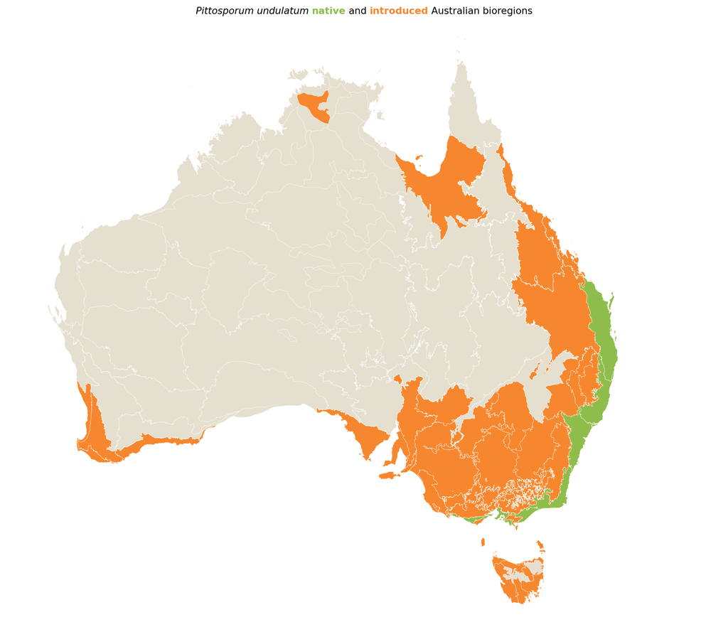

Figure 2: Map

```python
with plt.rc_context({"figure.figsize": (16, 11.5)}):
    bioregions.plot(edgecolor="white", linewidth = 0.25, color = bioregions["colour"])

    title_text = "<style:italic>Pittosporum undulatum</> <color:#8FBD4C, weight:bold>native</> and <color:#F7872E, weight:bold>introduced</> Australian bioregions"
    flexitext(0.5, 1, title_text, va="bottom", ha="center");

    plt.xlim([110, 161])
    plt.ylim([-45, -8])
    plt.axis("off")
    plt.show()
```

# Final thoughts

Human activity—from constructing buildings to travelling overseas to gardening—plays a part in shaping modern ecosystems. Our maps showed how quickly well-known invasive species have established themselves across Australia, and how widely even native Australian plants can spread when introduced to non-native regions.

Humans are just one of many drivers of introducing species to new areas. Changes to the environment, for example, can shrink available resources and living space in a habitat, giving introduced species a chance to outcompete native species for what resources and space are left. [As species inevitably enter and alter ecosystems](https://soe.dcceew.gov.au/overview/pressures/invasive-species-and-range-shifts#range-shifts-and-extensions), large weather events, extreme temperatures and habitat degradation [can give invasives a big leg-up on the native competition, too](https://theconversation.com/research-reveals-fire-is-pushing-88-of-australias-threatened-land-mammals-closer-to-extinction-185965).

Nonetheless, there is still hope. Research finds [native species can still adapt to changing environments](https://www.ecolsoc.org.au/news/native-plants-are-taking-back-their-homes/) and simple tasks like [pulling weeds](https://theconversation.com/pulling-out-weeds-is-the-best-thing-you-can-do-to-help-nature-recover-from-the-fires-130296) can help native species survive after events like fires.

**Expand for session info**

```python
import math
import natsort
import pandas
import session_info

session_info.show()
```

**Click to view session information**

```
-----
alphashape          1.3.1
dateutil            2.9.0.post0
flexitext           0.4.0
galah               0.13.6
geopandas           1.1.2
matplotlib          3.10.8
natsort             8.4.0
numpy               2.4.2
pandas              3.0.1
session_info        v1.0.1
shapely             2.1.2
-----
```

**Click to view modules imported as dependencies**

[output not shown]

[output cut: 26 more lines]

[output not shown]

```
-----
IPython             9.10.0
jupyter_client      8.9.1
jupyter_core        5.9.1
jupyterlab          4.6.2
notebook            7.6.1
-----
Python 3.14.3 (tags/v3.14.3:323c59a, Feb  3 2026, 16:04:56) [MSC v.1944 64 bit (AMD64)]
Windows-11-10.0.26100-SP0
-----
Session information updated at 2026-10-26 17:36
```

The ALA is made possible by contributions from its partners, is supported by [NCRIS](https://www.education.gov.au/national-collaborative-research-infrastructure-strategy-ncris), is hosted by [CSIRO](https://csiro.au/), and is the Australian node of [GBIF](https://www.gbif.org/en/).

**Acknowledgement of Traditional Owners and Country**

The Atlas of Living Australia acknowledges Australia's Traditional Owners and pays respect to the past and present Elders of the nation's Aboriginal and Torres Strait Islander communities. We honour and celebrate the spiritual, cultural and customary connections of Traditional Owners to country and the biodiversity that forms part of that country.

This work is licensed under a [Creative Commons Attribution 3.0 Australia License](https://creativecommons.org/licenses/by/3.0/au/)